# Assignment 10

Robert Wilbrand

20.1.21

```r
library(tidyverse)
library(raster)
library(GGally)
theme_set(theme_bw())
knitr::opts_knit$set(root.dir = "C:/MSc GCG/QM/Data/data")
knitr::opts_chunk$set(message = FALSE, warning = FALSE)
options(scipen = 8)
```

## 1. Draw 10,000 random samples from the bioclim dataset (bioclim.tif).

```r
# Import bioclim.tif
bioclim <- stack("bioclim.tif")

# Look at the structure of the stack
bioclim
```

```
## class      : RasterStack
## dimensions : 900, 2160, 1944000, 19  (nrow, ncol, ncell, nlayers)
## resolution : 0.1666667, 0.1666667  (x, y)
## extent     : -180, 180, -60, 90  (xmin, xmax, ymin, ymax)
## crs        : +proj=longlat +datum=WGS84 +no_defs
## names      : bioclim.1, bioclim.2, bioclim.3, bioclim.4, bioclim.5, bioclim.6, bioclim.7, bioclim.8, bioclim.9, bioclim.10, bioclim.11, bioclim.12, bioclim.13, bioclim.14, bioclim.15, ...
## min values :    -32768,    -32768,    -32768,    -32768,    -32768,    -32768,    -32768,    -32768,    -32768,     -32768,     -32768,     -32768,     -32768,     -32768,     -32768, ...
## max values :     32767,     32767,     32767,     32767,     32767,     32767,     32767,     32767,     32767,      32767,      32767,      32767,      32767,      32767,      32767, ...
```

```r
# Draw random sample
set.seed(645)
bioclim_smp <- sampleRandom(bioclim, 10000) %>% as_tibble
```

## 2. Conduct a principal component analysis on the bioclim samples in order to reduce the 19 climate variables to the most important principal components. Answer the following question (show your results).

1. How much variance (in percent) explain the first three components? How many components, do you think, are needed to describe (the majority of the variance of) the dataset and why?

```r
pca_bioclim <- prcomp(bioclim_smp, scale. = T)
pca_df <- (pca_bioclim$sdev^2/sum(pca_bioclim$sdev^2)*100) %>%
  bind_cols(1:19, ., cumsum(.)) %>%
  dplyr::rename(Component = ...1, ExplVar = ...2, CumVar = ...3)
slice(pca_df, 1:4)
```

```
## # A tibble: 4 x 3
##   Component ExplVar CumVar
##       <int>   <dbl>  <dbl>
## 1         1   51.9    51.9
## 2         2   25.2    77.2
## 3         3    7.54   84.7
## 4         4    5.58   90.3
```

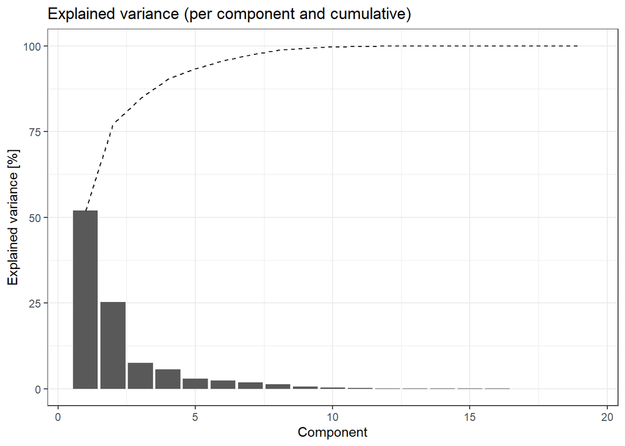

```r
ggplot(pca_df, aes(Component, ExplVar)) + geom_bar(stat = "identity") +
  geom_line(aes(Component, CumVar), linetype = 2) +
  labs(y = "Explained variance [%]",
  title = "Explained variance (per component and cumulative)")
```

The first 3 components combined explain 84.7% of the overall variance in the dataset. I would use 4 components total for further analysis. Combined, these account for 90.3% of the overall variance. The graph shows a leveling off for subsequent components, so not much additional information is gained by including these.

## 3. What information do the first three components (mainly) represent with respect to the input variables? Use the loadings/rotation coefficients of the first three components to answer this question.

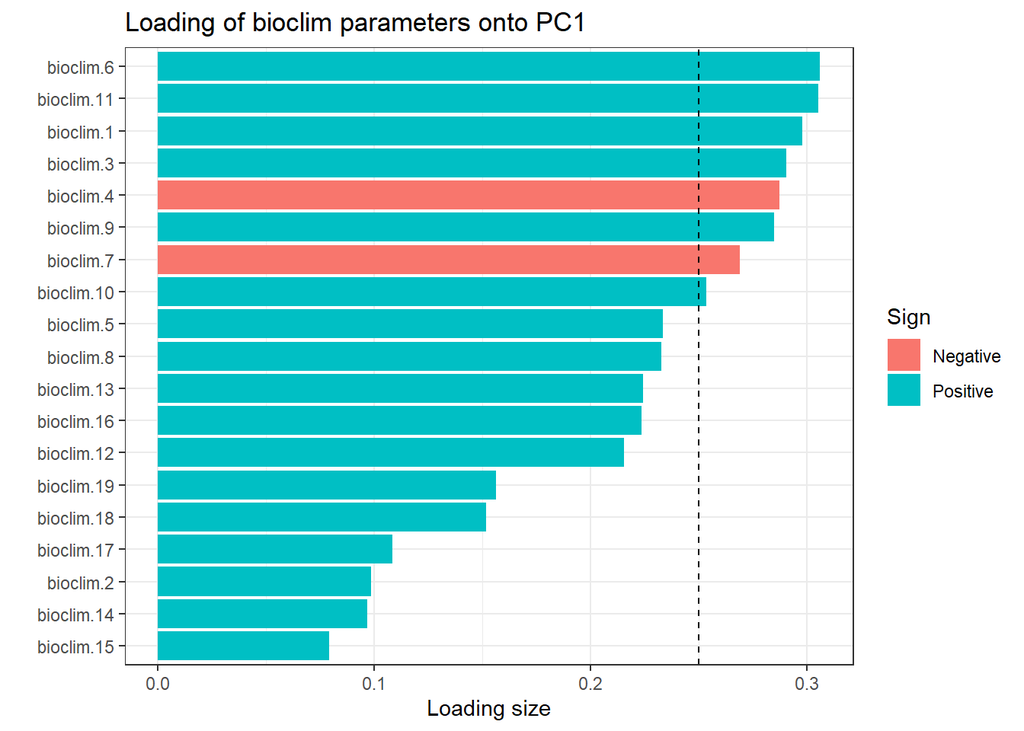

```r
# Extract PCs 1 to 3, split loading into direction and absolute value
loadings <- pca_bioclim$rotation[,1:3] %>%
  as.data.frame %>%
  rownames_to_column %>%
  as_tibble %>%
  mutate(across(rowname,
                ~factor(.x, levels = .))) %>%
  pivot_longer(2:4,
               names_to = "Component",
               values_to = "Loading") %>%
  mutate(Sign = ifelse(Loading >= 0,
                       "Positive",
                       "Negative"),
         AbsLoading = abs(Loading))

# Function to subset different PCs and create an ordered bar chart of loadings
# A line at 0.25 is used to aid visualization and cross-comparison
plot_loadings <- function(a){
  loadings %>%
    filter(Component == a) %>%
    mutate(across(rowname, ~fct_reorder(.x, AbsLoading))) %>%
    ggplot(aes(rowname, AbsLoading, fill = Sign)) +
    geom_bar(stat = "identity") +
    coord_flip() +
    labs(x = "", y = "Loading size",
         title = paste("Loading of bioclim parameters onto", a)) +
    geom_hline(yintercept = 0.25, linetype = 2)
}

plot_loadings("PC1")
```

Of the 19 Bioclim parameters, the first 11 relate to temperature, while the remaining 8 relate to precipitation. Although PC1 is not strongly dominated by any one particular parameter, it is noteworthy that 10 of the 11 temperature-related parameters have a larger (absolute) influence than any of the precipitation-related parameters.

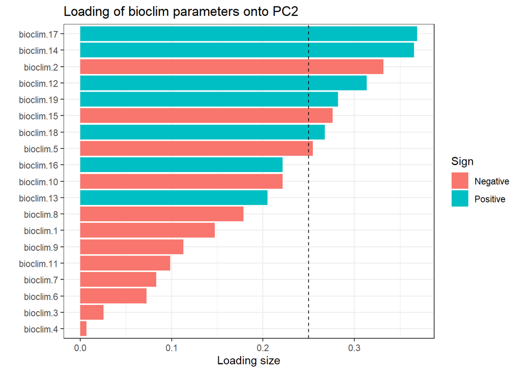

```r
plot_loadings("PC2")
```

Unlike with PC1, here precipitation-related parameters dominate, although no parameter in particular has a particularly high influence. The rank-influence profile is slightly steeper than in PC1, although still relatively even.

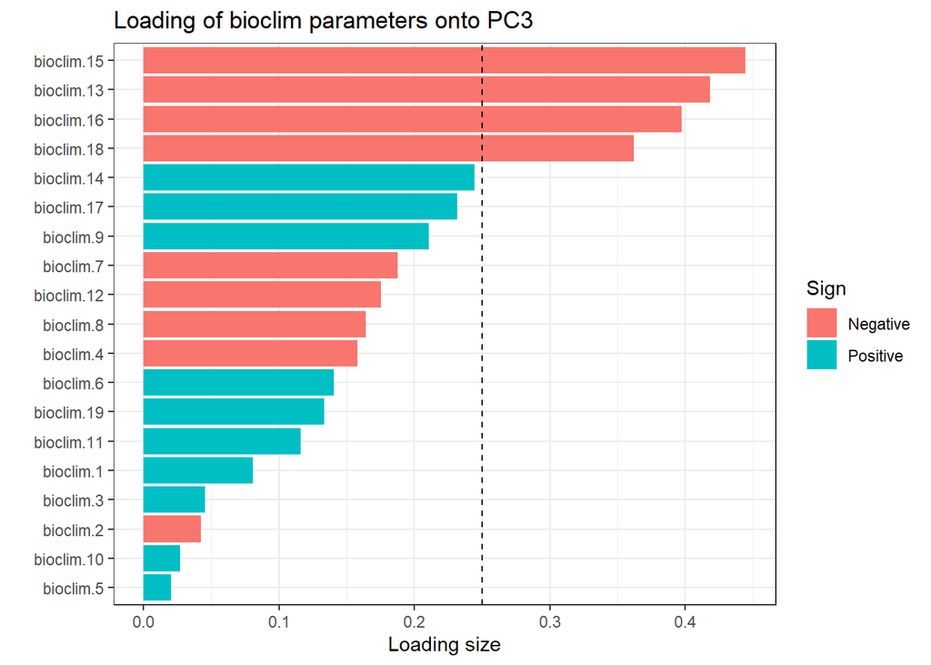

```r
plot_loadings("PC3")
```

Unlike PC1 and PC2, PC3 is heavily dominated by just 4 parameters, all of which have a negative effect and relate to precipitation.

## 4. Inspect the spatial predictions of the important principal components visually.

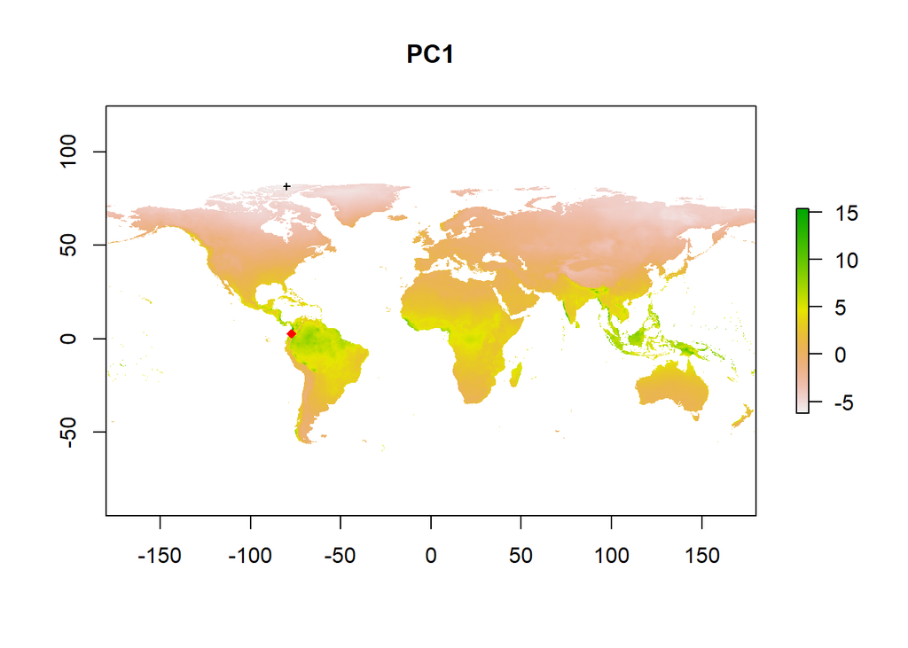

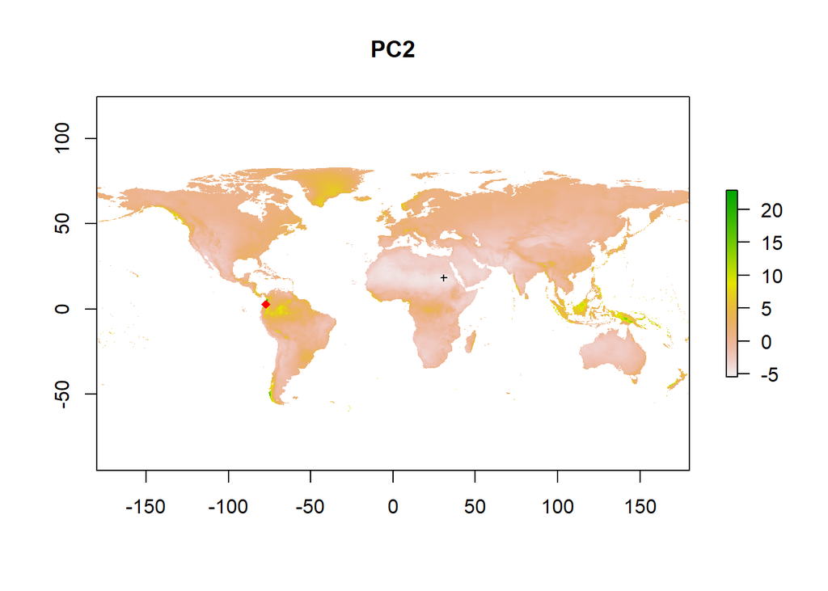

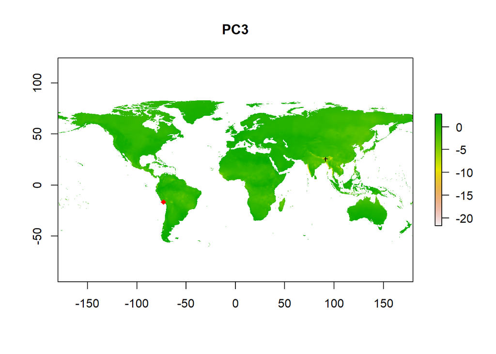

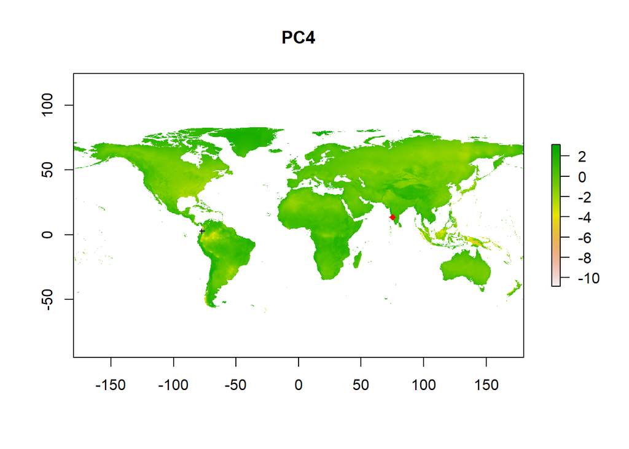

```r
pca_pred <- raster::predict(bioclim, pca_bioclim, index = 1:4)
pca_pred@data@names <- c("PC1","PC2","PC3","PC4")

# Plot selected layer of a raster with location of min and max values
minmaxplot <- function(rst, lyr = 1){
  rstlyr <- rst %>% subset(lyr)
  xymin <- which.min(rstlyr) %>% xyFromCell(rst, .)
  xymax <- which.max(rstlyr) %>% xyFromCell(rst, .)
  plot(rst, lyr)
  points(xymin, pch = 3, cex = 0.5)
  points(xymax, pch = 18, col = 'red')
}

# Plot each layer
walk(1:4, ~minmaxplot(pca_pred, .))
```